# Neural Networks: The Rise of the A.I. Guardians

## Year: 3075

### Background:

Humanity’s exodus to Earth Junior was a success—thanks to your incredible screening model. Over generations, humans have adapted to their new home, and peace has settled on Earth Junior. However, something strange has begun to occur among the advanced humanoid machines, called `Guardians`, who have served as protectors and caretakers for decades. Recently, a strange glitch has been detected in some Guardians. They exhibit erratic behaviors that resemble the old zombie behaviors from Earth. Scientists call this phenomenon `Code Rot` — an anomaly in the neural networks controlling the Guardians, possibly due to lingering cosmic radiation or a mysterious extraterrestrial virus.

As humanity’s chief machine learning engineer, you're tasked with identifying Guardians at risk of Code Rot. Using a neural network model, you need to predict which Guardians might develop this infection-like behavior. A high `Code Rot probability` indicates the Guardian is likely to malfunction, while a low score suggests it's safe.

*The mission is clear:* Identify and quarantine any malfunctioning Guardians before they jeopardize the safety of Earth Junior's inhabitants. But beware—time is limited, and the fate of humanity once again rests on your neural network’s ability to separate friend from foe.

[figure not shown]

### Problem Statement:

In this project, we will implement a binary classifier to predict whether a Guardian (humanoid machine) is infected with **Code Rot**—a malfunction that causes erratic behavior similar to a zombie-like state. The classifier will determine whether each Guardian is safe or infected based on CT scan images.

#### Data:

- **8580 CT scan images** of Guardians.
- A **CSV file** contains labels indicating whether each image corresponds to a malfunctioning (infected) Guardian or not.

We will develop a model that can accurately predict **whether there is infection or not** in these Guardians based on their CT scan images, and assess the performance using appropriate metrics.

## Import necessary libraries

```python
import numpy as np
import pandas as pd
import os
import matplotlib.pyplot as plt
from PIL import Image
import random
import torch
import torch.nn as nn
import torch.optim as optim

seed = None
np.random.seed(seed)
```

## Loading Data

Load the images, labels and preprocess

```python
image_folder = "data/HeadCT"
label_file = "data/labels.csv"

df = pd.read_csv(label_file)

#i have created an additional column
df['image_path'] = df['filename'].apply(lambda x: os.path.join(image_folder, x))

print(df.head())
```

```
      filename infected               image_path
0  000000.jpeg       no  data/HeadCT/000000.jpeg
1  000001.jpeg      yes  data/HeadCT/000001.jpeg
2  000002.jpeg      yes  data/HeadCT/000002.jpeg
3  000003.jpeg       no  data/HeadCT/000003.jpeg
4  000004.jpeg      yes  data/HeadCT/000004.jpeg
```

## Visualizing Data

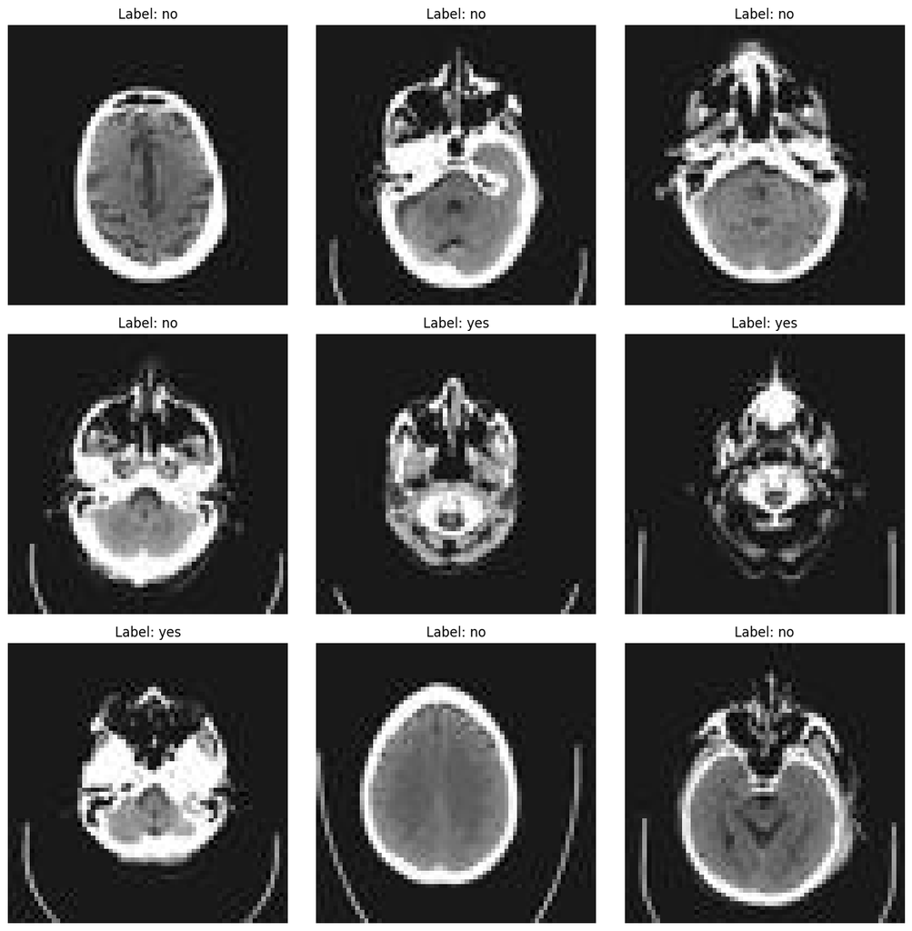

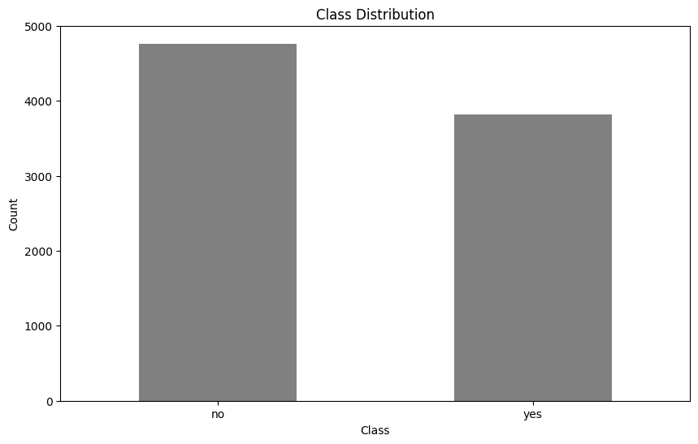

```python
def visualize_random_images(df, num_images=9):
    fig, axes = plt.subplots(3, 3, figsize=(12, 12))
    selected_images = random.sample(range(len(df)), num_images)

    for idx, ax in zip(selected_images, axes.ravel()):
        img_path = df.iloc[idx]['image_path']
        label = df.iloc[idx]['infected']
        img = Image.open(img_path)
        ax.imshow(img, cmap='gray')
        ax.set_title(f"Label: {label}")
        ax.axis('off')
    plt.tight_layout()
    plt.show()

def plot_class_distribution(df, bar_color='gray'):
    class_counts = df['infected'].value_counts()
    plt.figure(figsize=(10, 6))
    class_counts.plot(kind='bar', color=bar_color)
    plt.title("Class Distribution")
    plt.xlabel("Class")
    plt.ylabel("Count")
    plt.xticks(rotation=0)
    plt.show()


visualize_random_images(df)
plot_class_distribution(df)
```

## Train/test split and Normalization

- Performing train, test, val split using 60:20:20 split
- Implementing a suitable scaler class to normalize the data

```python
from sklearn.model_selection import train_test_split
from sklearn.preprocessing import LabelEncoder

def split_data(df, test_size=0.2, val_size=0.2, random_state=None):

    label_encoder = LabelEncoder()
    df['infected'] = label_encoder.fit_transform(df['infected'])

    train_val_df, test_df = train_test_split(df, test_size=test_size, random_state=random_state, stratify=df['infected'])

    val_size_adjusted = val_size / (1 - test_size)
    train_df, val_df = train_test_split(train_val_df, test_size=val_size_adjusted, random_state=random_state, stratify=train_val_df['infected'])

    print("Data Splits:")
    print(f"Training: {len(train_df)}, Validation: {len(val_df)}, Testing: {len(test_df)}")
    return train_df, val_df, test_df



train_df, val_df, test_df = split_data(df)
```

```
Data Splits:
Training: 5148, Validation: 1716, Testing: 1716
```

## Create a BinaryClassifier class

- Defining a model class, initialize layers with activations as required
- Defining a suitable loss function and learning rate

```python
class BinaryClassifier(nn.Module):
    def __init__(self, input_size):
        """
        Binary Classifier Model
        :param input_size: Number of input features (e.g., flattened image size)
        """
        super(BinaryClassifier, self).__init__()
        self.fc = nn.Sequential(
            nn.Linear(input_size, 128),
            nn.ReLU(),
            nn.Dropout(0.3),
            nn.Linear(128, 64),
            nn.ReLU(),
            nn.Dropout(0.3),
            nn.Linear(64, 1),
            nn.Sigmoid()
        )

    def forward(self, x):
        """
        Forward pass
        :param x: Input tensor
        """
        return self.fc(x)

input_size = 64 * 64

model = BinaryClassifier(input_size)

device = torch.device("cuda" if torch.cuda.is_available() else "cpu")
model.to(device)

loss_fn = nn.BCELoss()
optimizer = optim.Adam(model.parameters(), lr=0.001, weight_decay=1e-4)


print(model)
```

```
BinaryClassifier(
  (fc): Sequential(
    (0): Linear(in_features=4096, out_features=128, bias=True)
    (1): ReLU()
    (2): Dropout(p=0.3, inplace=False)
    (3): Linear(in_features=128, out_features=64, bias=True)
    (4): ReLU()
    (5): Dropout(p=0.3, inplace=False)
    (6): Linear(in_features=64, out_features=1, bias=True)
    (7): Sigmoid()
  )
)
```

## Training Loop

1. **`fit_one_epoch`**: Performs one epoch of training
2. **`evaluate`**: Evaluates the model on the validation set.
3. **`fit`**: Run all epochs, recording training and validation accuracies and losses

```python
def fit_one_epoch(model, dataloader, optimizer, loss_fn, device):
    model.train()
    running_loss = 0.0
    correct = 0
    total = 0

    for inputs, labels in dataloader:
        inputs, labels = inputs.to(device), labels.to(device)
        inputs = inputs.view(inputs.size(0), -1)

        optimizer.zero_grad()

        outputs = model(inputs).squeeze()
        loss = loss_fn(outputs, labels.float())

        loss.backward()
        optimizer.step()

        running_loss += loss.item()
        preds = (outputs >= 0.5).long()  # Threshold at 0.5
        correct += (preds == labels).sum().item()
        total += labels.size(0)

    epoch_loss = running_loss / len(dataloader)
    accuracy = correct / total
    return epoch_loss, accuracy


@torch.no_grad()
def evaluate(model, dataloader, loss_fn, device):
    model.eval()  # Set the model to evaluation mode
    running_loss = 0.0
    correct = 0
    total = 0

    for inputs, labels in dataloader:
        inputs, labels = inputs.to(device), labels.to(device)
        inputs = inputs.view(inputs.size(0), -1)
        outputs = model(inputs).squeeze()
        loss = loss_fn(outputs, labels.float())

        running_loss += loss.item()
        preds = (outputs >= 0.5).long()  # Threshold at 0.5
        correct += (preds == labels).sum().item()
        total += labels.size(0)

    epoch_loss = running_loss / len(dataloader)
    accuracy = correct / total
    return epoch_loss, accuracy


def fit(model, train_loader, val_loader, optimizer, loss_fn, device, epochs):

    train_losses, val_losses = [], []
    train_accuracies, val_accuracies = [], []
    scheduler = torch.optim.lr_scheduler.StepLR(optimizer, step_size=10, gamma=0.1)

    for epoch in range(epochs):
        train_loss, train_acc = fit_one_epoch(model, train_loader, optimizer, loss_fn, device)
        train_losses.append(train_loss)
        train_accuracies.append(train_acc)



        val_loss, val_acc = evaluate(model, val_loader, loss_fn, device)
        val_losses.append(val_loss)
        val_accuracies.append(val_acc)


        scheduler.step()

        print(f"Epoch {epoch+1}/{epochs}")
        print(f"  Train Loss: {train_loss:.4f}, Train Acc: {train_acc:.4f}")
        print(f"  Val Loss:   {val_loss:.4f}, Val Acc:   {val_acc:.4f}")

    return train_losses, train_accuracies, val_losses, val_accuracies
```

```python
from torch.utils.data import Dataset
from torch.utils.data import DataLoader
from torchvision import transforms


transform = transforms.Compose([
    transforms.Grayscale(),
    transforms.Resize((64, 64)),
    transforms.ToTensor(),
    transforms.Normalize((0.5,), (0.5,))
])




class MakeDataset(Dataset):
    def __init__(self, dataframe, transform=None):
        self.dataframe = dataframe
        self.transform = transform

    def __len__(self):
        return len(self.dataframe)

    def __getitem__(self, idx):
        img_path = self.dataframe.iloc[idx]['image_path']
        label = self.dataframe.iloc[idx]['infected']
        image = Image.open(img_path)
        if self.transform:
            image = self.transform(image)
        return image, torch.tensor(label, dtype=torch.float32)


# Create Dataset and DataLoader
train_dataset = MakeDataset(train_df, transform=transform)
val_dataset = MakeDataset(val_df, transform=transform)
test_dataset = MakeDataset(test_df, transform=transform)

train_loader = DataLoader(train_dataset, batch_size=256, shuffle=True)
val_loader = DataLoader(val_dataset, batch_size=128, shuffle=False)
test_loader = DataLoader(val_dataset, batch_size=128, shuffle=True)
```

```python
epochs = 100
train_losses, train_accuracies, val_losses, val_accuracies = fit(
    model, train_loader, val_loader, optimizer, loss_fn, device, epochs
)
```

[output not shown]

[output cut: 145 more lines]

```
  Val Loss:   0.0211, Val Acc:   0.9901
  Train Loss: 0.0051, Train Acc: 0.9986
  Val Loss:   0.0211, Val Acc:   0.9901
  Train Loss: 0.0046, Train Acc: 0.9992
  Val Loss:   0.0211, Val Acc:   0.9901
  Train Loss: 0.0053, Train Acc: 0.9988
  Val Loss:   0.0211, Val Acc:   0.9901
  Train Loss: 0.0049, Train Acc: 0.9984
  Val Loss:   0.0211, Val Acc:   0.9901
  Train Loss: 0.0047, Train Acc: 0.9992
  Val Loss:   0.0211, Val Acc:   0.9901
  Train Loss: 0.0045, Train Acc: 0.9992
  Val Loss:   0.0211, Val Acc:   0.9901
  Train Loss: 0.0040, Train Acc: 1.0000
  Val Loss:   0.0211, Val Acc:   0.9901
```

## Plotting Accuracy and Loss Curves

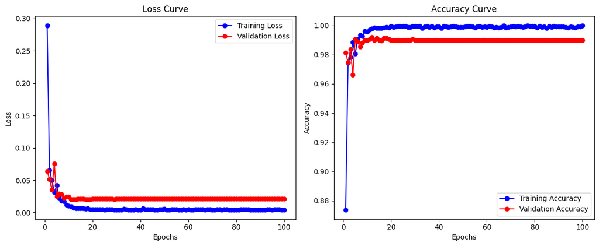

```python
import matplotlib.pyplot as plt

def plot_training_curves(train_losses, train_accuracies, val_losses, val_accuracies):
    epochs = range(1, len(train_losses) + 1)

    plt.figure(figsize=(12, 5))
    plt.subplot(1, 2, 1)
    plt.plot(epochs, train_losses, 'b-o', label="Training Loss")
    plt.plot(epochs, val_losses, 'r-o', label="Validation Loss")
    plt.title("Loss Curve")
    plt.xlabel("Epochs")
    plt.ylabel("Loss")
    plt.legend()

    plt.subplot(1, 2, 2)
    plt.plot(epochs, train_accuracies, 'b-o', label="Training Accuracy")
    plt.plot(epochs, val_accuracies, 'r-o', label="Validation Accuracy")
    plt.title("Accuracy Curve")
    plt.xlabel("Epochs")
    plt.ylabel("Accuracy")
    plt.legend()

    plt.tight_layout()
    plt.show()

# Call the function with results from the fit function
plot_training_curves(train_losses, train_accuracies, val_losses, val_accuracies)
```

```python
# Evaluate on test set
test_loss, test_accuracy = evaluate(model, test_loader, loss_fn, device)

print(f"Test Loss: {test_loss:.4f}")
print(f"Test Accuracy: {test_accuracy:.4f}")
```

```
Test Loss: 0.0220
Test Accuracy: 0.9901
```

## Evaluation Metrics

- Classification Report
- Confusion Matrix
- ROC Curve

```
Classification Report:
              precision    recall  f1-score   support

Not Infected       0.99      0.99      0.99       953
    Infected       0.99      0.99      0.99       763

    accuracy                           0.99      1716
   macro avg       0.99      0.99      0.99      1716
weighted avg       0.99      0.99      0.99      1716

Confusion Matrix:
[[943  10]
 [  7 756]]
```

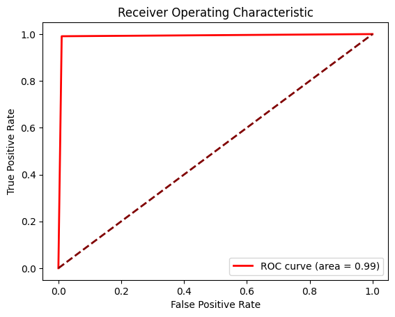

```python
from sklearn.metrics import classification_report, confusion_matrix

all_preds = []
all_labels = []

for inputs, labels in test_loader:
    inputs, labels = inputs.to(device), labels.to(device)
    inputs = inputs.view(inputs.size(0), -1)  # Flatten images
    outputs = model(inputs).squeeze()
    preds = (outputs >= 0.5).long()
    all_preds.extend(preds.cpu().numpy())
    all_labels.extend(labels.cpu().numpy())

print("Classification Report:")
print(classification_report(all_labels, all_preds, target_names=["Not Infected", "Infected"]))

print("Confusion Matrix:")
print(confusion_matrix(all_labels, all_preds))

from sklearn.metrics import roc_curve, auc

fpr, tpr, thresholds = roc_curve(all_labels, all_preds)
roc_auc = auc(fpr, tpr)

plt.figure()
plt.plot(fpr, tpr, color="red", lw=2, label=f"ROC curve (area = {roc_auc:.2f})")
plt.plot([0, 1], [0, 1], color="maroon", lw=2, linestyle="--")
plt.xlabel("False Positive Rate")
plt.ylabel("True Positive Rate")
plt.title("Receiver Operating Characteristic")
plt.legend(loc="lower right")
plt.show()
```

## Where did it go wrong?

Plotting images that were missclassified by the model to see where it struggled to differentiate between the classes

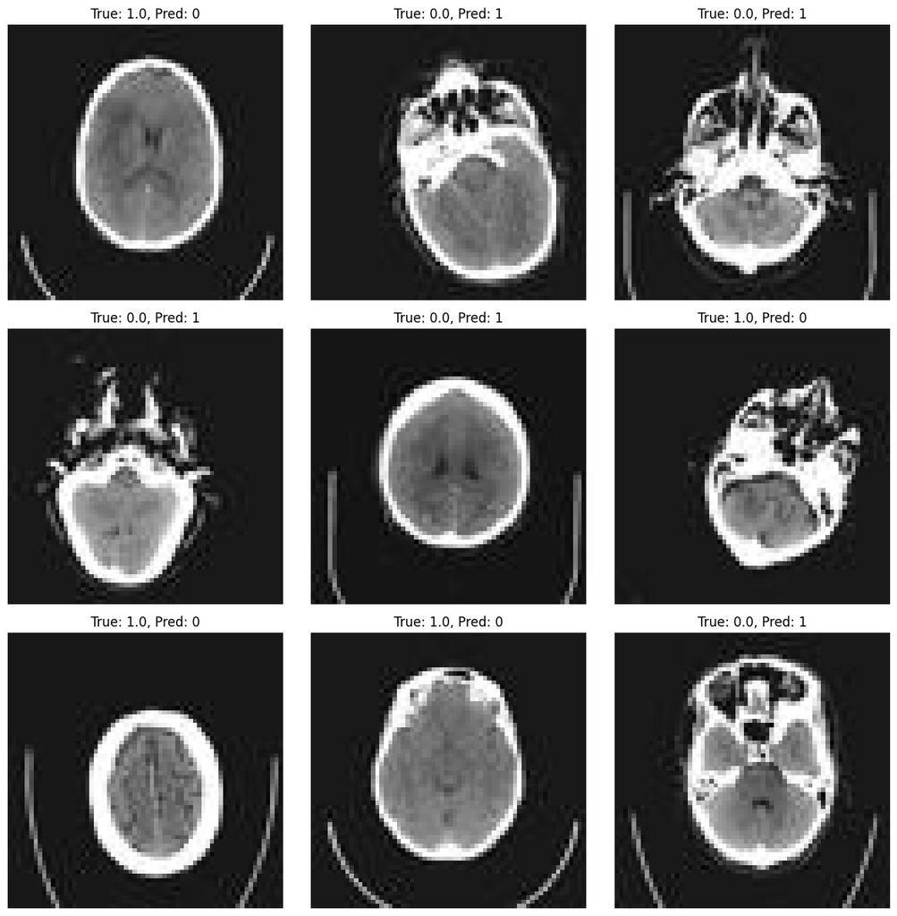

```python
def visualize_misclassified_examples(model, test_loader, device):

    model.eval()  # Set the model to evaluation mode
    misclassified = []

    with torch.no_grad():
        for inputs, labels in test_loader:
            inputs, labels = inputs.to(device), labels.to(device)
            inputs = inputs.view(inputs.size(0), -1)
            outputs = model(inputs).squeeze()
            preds = (outputs >= 0.5).long()


            for i in range(len(preds)):
                if preds[i] != labels[i]:  # If prediction is wrong
                    misclassified.append((inputs[i].cpu(), labels[i].item(), preds[i].item()))


    num_to_display = min(9, len(misclassified))  # Display up to 9 examples
    if num_to_display == 0:
        print("No misclassified examples to display.")
        return

    fig, axes = plt.subplots(3, 3, figsize=(12, 12))
    for idx, ax in enumerate(axes.ravel()[:num_to_display]):
        image, true_label, predicted_label = misclassified[idx]
        image = image.view(64, 64).numpy()  # Reshape back to 2D
        ax.imshow(image, cmap='gray')
        ax.set_title(f"True: {true_label}, Pred: {predicted_label}")
        ax.axis('off')

    plt.tight_layout()
    plt.show()

# Call the function
visualize_misclassified_examples(model, test_loader, device)
```

## Well done, Guardian Protector! 🎉

Our model has successfully safeguarded Earth Junior from Code Rot, ensuring few more years of peace and security.